# ITS2 alpha preliminary diversity analysis

Coverage-based curve

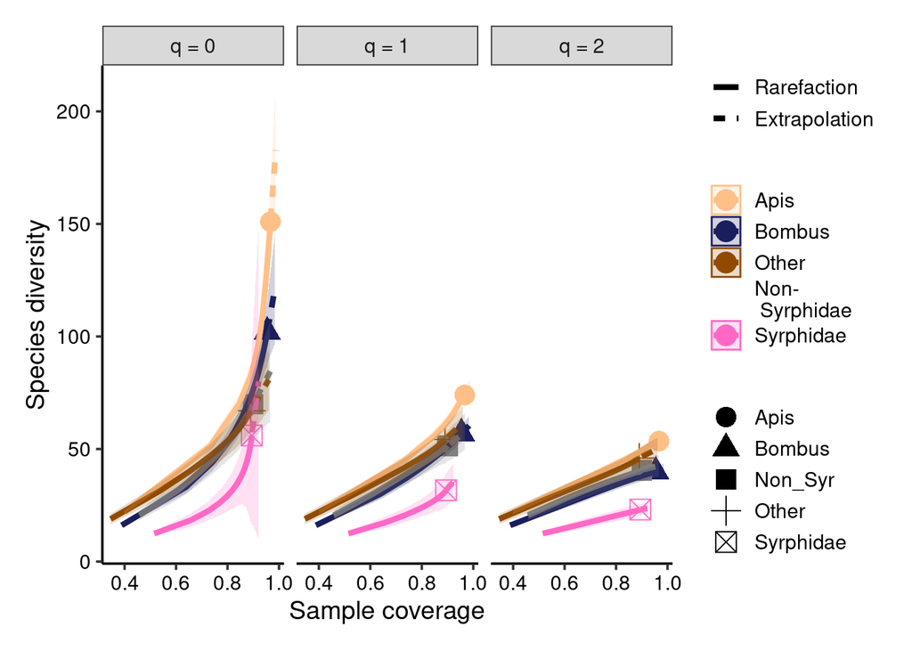

```r
# Coverage-based R/E curve (type=3): see
# Figs. 1c and 2c in Hsieh et al. (2016).
# This curve plots the diversity estimates
# with confidence intervals (if se=TRUE) as
# a function of sample coverage up to the
# maximum coverage obtained from the maximum
# size described in (1)

bichos_coverage_curve <- ggiNEXT(inext_pollen,
    type = 3, facet.var = "Order.q")

bichos_coverage_curve_p <- bichos_coverage_curve +
    bichos_color + bichos_fill + pca_theme + theme_set(theme_bw(base_size = 14)) +
    theme(axis.line = element_line(colour = "black"),
        panel.grid.major = element_blank(), panel.grid.minor = element_blank(),
        panel.background = element_blank(), panel.border = element_blank(),
        plot.margin = grid::unit(c(5, 5, 5, 5),
            "mm"), axis.text.x = element_text(colour = "black",
            size = rel(1)), axis.text.y = element_text(size = rel(1),
            colour = "black"), axis.title = element_text(size = rel(1)))

bichos_coverage_curve_p
```

```r
png(paste0(outputDir, "/Figures/pollen_bichos_RE_curve.png"),
    width = 3000, height = 1700, res = 230)
bichos_coverage_curve_p
dev.off()
```

Bichos Hill numbers estimates (coverageD)

```r
coverage_incidence$ID <- paste("Incidence", coverage_incidence$Assemblage,
    coverage_incidence$Order.q, sep = "_")

coverage_incidence_long <- coverage_incidence %>%
    select(-Assemblage, -Order.q, -t, -Method,
        -SC) %>%
    pivot_longer(!ID, names_to = "iNEXT_est",
        values_to = "estimate") %>%
    mutate(ID = str_replace(ID, "Non_Syr", "Non-Syrphidae"))

coverage_bichos <- coverage_incidence_long %>%
    separate_wider_delim(cols = ID, delim = "_",
        names = c("Data_type", "Bichos", "Hill_number"))
```

PLot Incidence Data (coverage)

```r
richness_coverage_p <- coverage_bichos %>%
    filter(Hill_number == "0") %>%
    pivot_wider(names_from = "iNEXT_est", values_from = "estimate") %>%
    ggplot(aes(x = Bichos, y = qD, group = 1)) +
    geom_errorbar(width = 0.1, aes(ymin = qD.LCL,
        ymax = qD.UCL)) + geom_point(shape = 21,
    size = 4, fill = "grey") + xlab("") + ylab("Richness") +
    div_theme + theme(axis.text.x = element_text(face = "italic",
    angle = 45, vjust = 0.9, hjust = 1))

shannon_coverage_p <- coverage_bichos %>%
    filter(Hill_number == "1") %>%
    pivot_wider(names_from = "iNEXT_est", values_from = "estimate") %>%
    ggplot(aes(x = Bichos, y = qD, group = 1)) +
    geom_errorbar(width = 0.1, aes(ymin = qD.LCL,
        ymax = qD.UCL)) + geom_point(shape = 21,
    size = 4, fill = "grey") + xlab("") + ylab("Hill-Shannon") +
    div_theme + theme(axis.text.x = element_text(face = "italic",
    angle = 45, vjust = 0.9, hjust = 1))

simpson_coverage_p <- coverage_bichos %>%
    filter(Hill_number == "2") %>%
    pivot_wider(names_from = "iNEXT_est", values_from = "estimate") %>%
    ggplot(aes(x = Bichos, y = qD, group = 1)) +
    geom_errorbar(width = 0.1, aes(ymin = qD.LCL,
        ymax = qD.UCL)) + geom_point(shape = 21,
    size = 4, fill = "grey") + xlab("") + ylab("Hill-Simpson") +
    div_theme + theme(axis.text.x = element_text(face = "italic",
    angle = 45, vjust = 0.9, hjust = 1))

alpha_pollen_bichos_p <- ggarrange(richness_coverage_p,
    shannon_coverage_p, simpson_coverage_p, nrow = 1)
alpha_pollen_bichos_p
```

[output not shown]

## Hill diversity estimates using hilldiv package

Prepare hilldiv data

```r
df_species <- data.frame(otu_table(ps_pollen_filt_Species))

colnames(df_species) <- paste(as.data.frame(tax_table(ps_pollen_filt_Species))$Genus,
    as.data.frame(tax_table(ps_pollen_filt_Species))$Species,
    sep = "_")

colnames(df_species) <- str_replace(colnames(df_species),
    pattern = ".?Genus+.*", replacement = "_sp.")


asv_species_abund <- data.frame(t(df_species))

asv_species_relabund <- data.frame(t(df_species))

asv_species_to_incidence_fruitcrop <- to.incidence(asv_species_abund,
    pollen_hier_crop[, c(1, 2)])

asv_species_to_occurrence <- to.occurrences(asv_species_abund)

asv_species_to_incidence_bichos <- to.incidence(asv_species_abund,
    pollen_hier_crop[, c(1, 5)])
```

### Distance matrix (occurrence data)

```r
dist_q0 <- pair_dis(asv_species_to_occurrence,
    qvalue = 0)
dist_q1 <- pair_dis(asv_species_to_occurrence,
    qvalue = 1)
dist_q2 <- pair_dis(asv_species_to_occurrence,
    qvalue = 2)

sorensen_dist_q0 <- as.dist(dist_q0$L1_CqN)
sorensen_dist_q1 <- as.dist(dist_q1$L1_CqN)
sorensen_dist_q2 <- as.dist(dist_q2$L1_CqN)

# write.csv(sorensen_dist, paste0(dataDir,
# '/Sorensen_Hill_distance.csv'))
```

Test whether the the grouping factor (fruitcrop) has a significant effect on overall plant species composition based on incidence data.

```r
nrow(pollen_hier_crop)
```

```
## [1] 156
```

```r
occurrence_permanova_q0 <- adonis2(t(sorensen_dist_q0) ~
    Fruitcrop, data = pollen_hier_crop, permutations = 9999,
    na.rm = TRUE)
occurrence_permanova_q0
```

```
## Permutation test for adonis under reduced model
## Terms added sequentially (first to last)
## Permutation: free
## Number of permutations: 9999
##
## adonis2(formula = t(sorensen_dist_q0) ~ Fruitcrop, data = pollen_hier_crop, permutations = 9999, na.rm = TRUE)
##            Df SumOfSqs      R2      F Pr(>F)
## Fruitcrop   3    4.679 0.13163 7.6801  1e-04 ***
## Residual  152   30.869 0.86837
## Total     155   35.548 1.00000
## ---
## Signif. codes:  0 '***' 0.001 '**' 0.01 '*' 0.05 '.' 0.1 ' ' 1
```

```r
occurrence_permanova_q1 <- adonis2(t(sorensen_dist_q1) ~
    Fruitcrop, data = pollen_hier_crop, permutations = 9999,
    na.rm = TRUE)
occurrence_permanova_q1
```

```
## Permutation test for adonis under reduced model
## Terms added sequentially (first to last)
## Permutation: free
## Number of permutations: 9999
##
## adonis2(formula = t(sorensen_dist_q1) ~ Fruitcrop, data = pollen_hier_crop, permutations = 9999, na.rm = TRUE)
##            Df SumOfSqs      R2      F Pr(>F)
## Fruitcrop   3    4.586 0.13269 7.7517  1e-04 ***
## Residual  152   29.977 0.86731
## Total     155   34.563 1.00000
## ---
## Signif. codes:  0 '***' 0.001 '**' 0.01 '*' 0.05 '.' 0.1 ' ' 1
```

```r
occurrence_permanova_q2 <- adonis2(t(sorensen_dist_q2) ~
    Fruitcrop, data = pollen_hier_crop, permutations = 9999,
    na.rm = TRUE)
occurrence_permanova_q2
```

```
## Permutation test for adonis under reduced model
## Terms added sequentially (first to last)
## Permutation: free
## Number of permutations: 9999
##
## adonis2(formula = t(sorensen_dist_q2) ~ Fruitcrop, data = pollen_hier_crop, permutations = 9999, na.rm = TRUE)
##            Df SumOfSqs      R2      F Pr(>F)
## Fruitcrop   3    4.679 0.13163 7.6801  1e-04 ***
## Residual  152   30.869 0.86837
## Total     155   35.548 1.00000
## ---
## Signif. codes:  0 '***' 0.001 '**' 0.01 '*' 0.05 '.' 0.1 ' ' 1
```

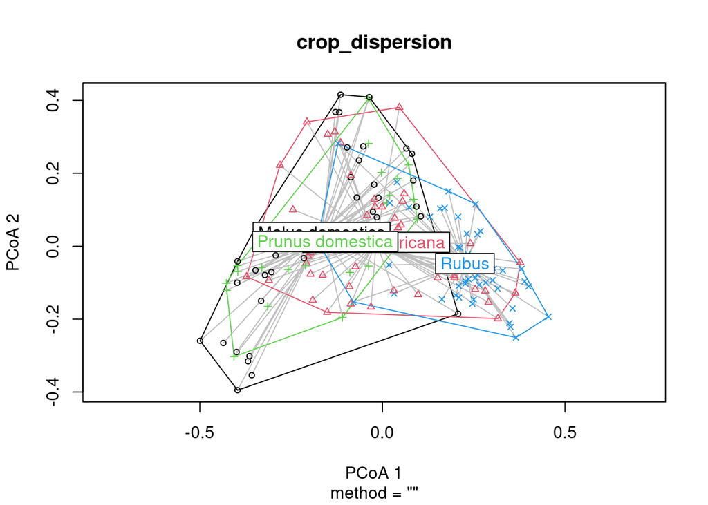

```r
# Fruitcrop 3 4.694 0.12932 7.5751 1e-04 ***

# Calculate multivariate dispersions
crop_dispersion <- betadisper(t(sorensen_dist_q1),
    pollen_hier_crop$Fruitcrop)

plot(crop_dispersion)
```

```r
# test for differences in dispersion
anova(crop_dispersion)
```

```
## Analysis of Variance Table
##
## Response: Distances
##            Df Sum Sq  Mean Sq F value Pr(>F)
## Groups      3 0.0702 0.023401   1.641 0.1823
## Residuals 152 2.1676 0.014260
```

```r
# Permutation test for F
permutest(crop_dispersion, pairwise = TRUE, permutations = 99)
```

```
##
## Permutation test for homogeneity of multivariate dispersions
## Permutation: free
## Number of permutations: 99
##
## Response: Distances
##            Df Sum Sq  Mean Sq     F N.Perm Pr(>F)
## Groups      3 0.0702 0.023401 1.641     99   0.16
## Residuals 152 2.1676 0.014260
##
## Pairwise comparisons:
## (Observed p-value below diagonal, permuted p-value above diagonal)
##                  Malus domestica Persea americana Prunus domestica Rubus
## Malus domestica                          0.040000         0.770000  0.40
## Persea americana        0.142187                          0.310000  0.04
## Prunus domestica        0.780029         0.310797                   0.49
## Rubus                   0.444842         0.060957         0.439307
```

```r
## Tukey's Honest Significant Differences
(crop_HSD <- TukeyHSD(crop_dispersion))
```

```
##   Tukey multiple comparisons of means
##     95% family-wise confidence level
##
## Fit: aov(formula = distances ~ group, data = df)
##
## $group
##                                           diff         lwr         upr
## Persea americana-Malus domestica   0.032278382 -0.03524407 0.099800836
## Prunus domestica-Malus domestica   0.005927857 -0.07678466 0.088640376
## Rubus-Malus domestica             -0.021853443 -0.08842075 0.044713861
## Prunus domestica-Persea americana -0.026350525 -0.10676129 0.054060237
## Rubus-Persea americana            -0.054131825 -0.11781648 0.009552833
## Rubus-Prunus domestica            -0.027781300 -0.10739169 0.051829093
##                                       p adj
## Persea americana-Malus domestica  0.6013255
## Prunus domestica-Malus domestica  0.9977016
## Rubus-Malus domestica             0.8289837
## Prunus domestica-Persea americana 0.8297474
## Rubus-Persea americana            0.1256799
## Rubus-Prunus domestica            0.8014012
```

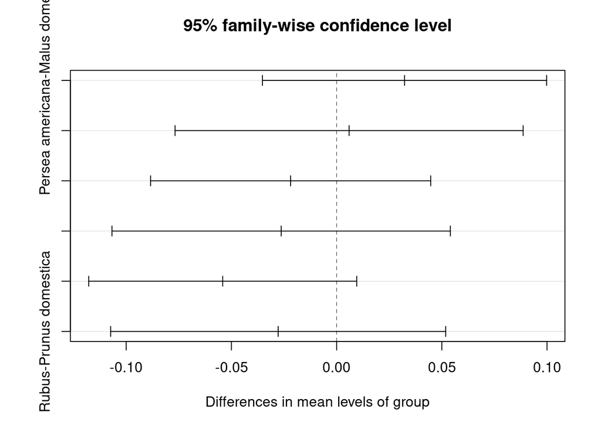

```r
plot(crop_HSD)
```

> Fruit crop explains 13% of the variation in community composition of plant sources from pollen in insect visitors. There was no difference in dispersion

Test whether the the grouping factor (insect group) has a significant effect on overall plant species composition based on incidence data.

```r
occurrence_permanova_q0 <- adonis2(t(sorensen_dist_q0) ~
    Bichos_group, data = pollen_hier_crop, permutations = 9999,
    na.rm = TRUE)
occurrence_permanova_q0
```

```
## Permutation test for adonis under reduced model
## Terms added sequentially (first to last)
## Permutation: free
## Number of permutations: 9999
##
## adonis2(formula = t(sorensen_dist_q0) ~ Bichos_group, data = pollen_hier_crop, permutations = 9999, na.rm = TRUE)
##               Df SumOfSqs      R2      F Pr(>F)
## Bichos_group   4    2.109 0.05933 2.3808  2e-04 ***
## Residual     151   33.439 0.94067
## Total        155   35.548 1.00000
## ---
## Signif. codes:  0 '***' 0.001 '**' 0.01 '*' 0.05 '.' 0.1 ' ' 1
```

```r
occurrence_permanova_q1 <- adonis2(t(sorensen_dist_q1) ~
    Bichos_group, data = pollen_hier_crop, permutations = 9999,
    na.rm = TRUE)
occurrence_permanova_q1
```

```
## Permutation test for adonis under reduced model
## Terms added sequentially (first to last)
## Permutation: free
## Number of permutations: 9999
##
## adonis2(formula = t(sorensen_dist_q1) ~ Bichos_group, data = pollen_hier_crop, permutations = 9999, na.rm = TRUE)
##               Df SumOfSqs      R2      F Pr(>F)
## Bichos_group   4    2.058 0.05953 2.3896  1e-04 ***
## Residual     151   32.506 0.94047
## Total        155   34.563 1.00000
## ---
## Signif. codes:  0 '***' 0.001 '**' 0.01 '*' 0.05 '.' 0.1 ' ' 1
```

```r
occurrence_permanova_q2 <- adonis2(t(sorensen_dist_q2) ~
    Bichos_group, data = pollen_hier_crop, permutations = 9999,
    na.rm = TRUE)
occurrence_permanova_q2
```

```
## Permutation test for adonis under reduced model
## Terms added sequentially (first to last)
## Permutation: free
## Number of permutations: 9999
##
## adonis2(formula = t(sorensen_dist_q2) ~ Bichos_group, data = pollen_hier_crop, permutations = 9999, na.rm = TRUE)
##               Df SumOfSqs      R2      F Pr(>F)
## Bichos_group   4    2.109 0.05933 2.3808  2e-04 ***
## Residual     151   33.439 0.94067
## Total        155   35.548 1.00000
## ---
## Signif. codes:  0 '***' 0.001 '**' 0.01 '*' 0.05 '.' 0.1 ' ' 1
```

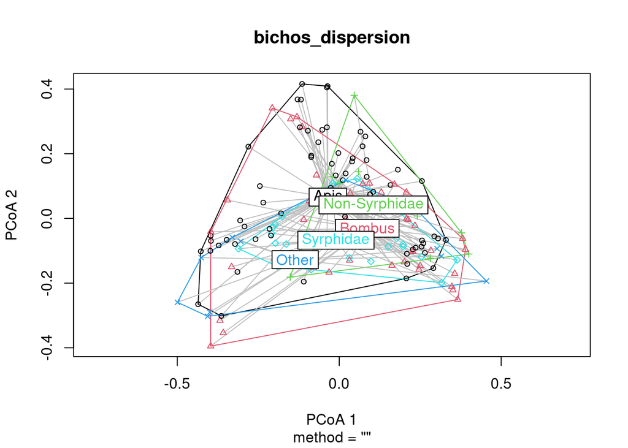

```r
# Calculate multivariate dispersions
bichos_dispersion <- betadisper(t(sorensen_dist_q1),
    pollen_hier_crop$Bichos_group)

plot(bichos_dispersion)
```

```r
# test for differences in dispersion
anova(bichos_dispersion)
```

```
## Analysis of Variance Table
##
## Response: Distances
##            Df  Sum Sq  Mean Sq F value Pr(>F)
## Groups      4 0.06615 0.016538  1.4765 0.2121
## Residuals 151 1.69139 0.011201
```

```r
# Permutation test for F
permutest(bichos_dispersion, pairwise = TRUE,
    permutations = 99)
```

```
##
## Permutation test for homogeneity of multivariate dispersions
## Permutation: free
## Number of permutations: 99
##
## Response: Distances
##            Df  Sum Sq  Mean Sq      F N.Perm Pr(>F)
## Groups      4 0.06615 0.016538 1.4765     99   0.15
## Residuals 151 1.69139 0.011201
##
## Pairwise comparisons:
## (Observed p-value below diagonal, permuted p-value above diagonal)
##                  Apis  Bombus Non-Syrphidae   Other Syrphidae
## Apis                  0.09000       0.17000 0.27000      0.35
## Bombus        0.12198               0.13000 0.82000      0.20
## Non-Syrphidae 0.13739 0.15318               0.12000      0.77
## Other         0.28883 0.88804       0.14213              0.28
## Syrphidae     0.35003 0.16865       0.75604 0.31862
```

```r
## Tukey's Honest Significant Differences
(bichos_HSD <- TukeyHSD(bichos_dispersion))
```

```
##   Tukey multiple comparisons of means
##     95% family-wise confidence level
##
## Fit: aov(formula = distances ~ group, data = df)
##
## $group
##                                 diff         lwr        upr     p adj
## Bombus-Apis              0.031799076 -0.02539026 0.08898841 0.5413270
## Non-Syrphidae-Apis      -0.032143569 -0.12354018 0.05925304 0.8678056
## Other-Apis               0.025142330 -0.06972722 0.12001188 0.9487910
## Syrphidae-Apis          -0.019538663 -0.09108503 0.05200770 0.9431300
## Non-Syrphidae-Bombus    -0.063942646 -0.15959251 0.03170722 0.3514107
## Other-Bombus            -0.006656746 -0.10563042 0.09231693 0.9997315
## Syrphidae-Bombus        -0.051337740 -0.12824312 0.02556765 0.3528967
## Other-Non-Syrphidae      0.057285899 -0.06469159 0.17926339 0.6936580
## Syrphidae-Non-Syrphidae  0.012604906 -0.09226243 0.11747224 0.9973578
## Syrphidae-Other         -0.044680993 -0.15258859 0.06322661 0.7832424
```

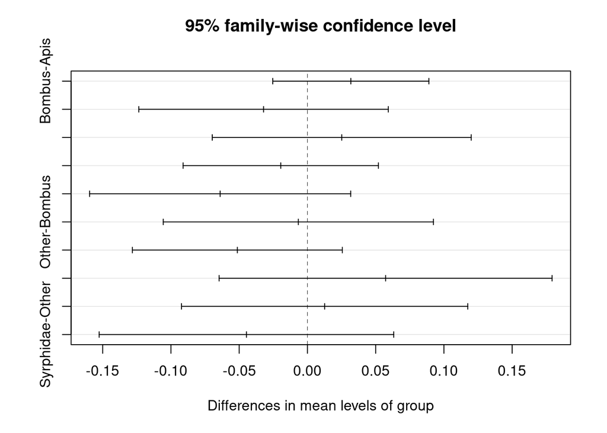

```r
plot(bichos_HSD)
```

> Plant community composition is significantly different between insect group but the variance explained by this predictor is lower than that explained by fruit crop.

Perform a NMDS

```r
# run NMDS q0
set.seed(20102023)
values_NMDS_q0 <- metaMDS(as.dist(sorensen_dist_q0),
    k = 4, trymax = 500)
```

```
## *** Best solution repeated 1 times
```

```r
values_NMDS_q0$stress
```

```
## [1] 0.1248116
```

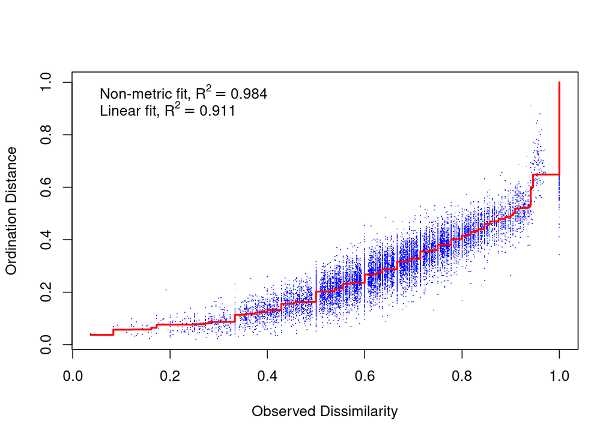

```r
stressplot(values_NMDS_q0)
```

```r
# run NMDS q1
set.seed(20102023)
values_NMDS_q1 <- metaMDS(as.dist(sorensen_dist_q1),
    k = 4, trymax = 500)
```

```
## *** Best solution repeated 1 times
```

```r
values_NMDS_q1$stress
```

```
## [1] 0.1325314
```

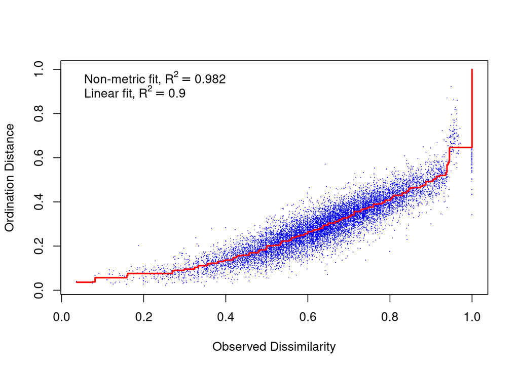

```r
stressplot(values_NMDS_q1)
```

```r
# run NMDS q2
set.seed(20102023)
values_NMDS_q2 <- metaMDS(as.dist(sorensen_dist_q2),
    k = 4, trymax = 500)
```

```
## *** Best solution repeated 1 times
```

```r
values_NMDS_q2$stress
```

```
## [1] 0.1248116
```

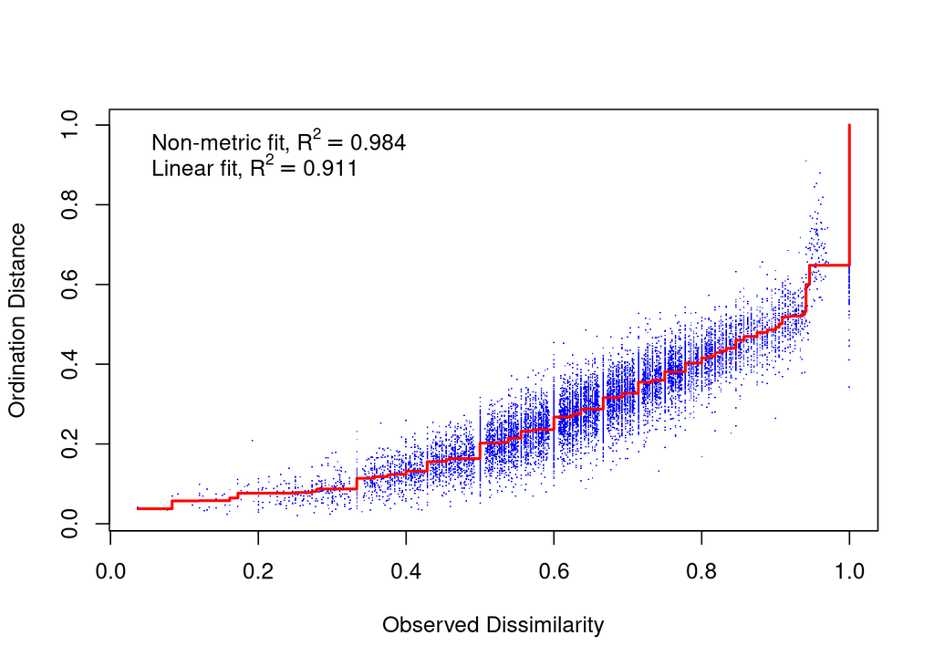

```r
stressplot(values_NMDS_q2)
```

NMDS values for fruit crop plot

```r
NMDS_scores_q0 <- data.frame(NMDS1 = values_NMDS_q0$point[,
    1], NMDS2 = values_NMDS_q0$point[, 2], NMDS3 = values_NMDS_q0$point[,
    3], NMDS4 = values_NMDS_q0$point[, 4], Group = as.factor(pollen_hier_crop[,
    2]))

NMDS_centroids_q0 = aggregate(NMDS_scores_q0[,
    c(1:2)], by = list(NMDS_scores_q0[, 5]), FUN = mean)

table(NMDS_scores_q0$Group)
```

```
##
##  Malus domestica Persea americana Prunus domestica            Rubus
##               39               46               22               49
```

```r
NMDS_scores_q0$Sample <- rownames(NMDS_scores_q0)

colnames(NMDS_centroids_q0) <- c("Group", "x_cen",
    "y_cen")

NMDS_scores_q0 <- merge(NMDS_scores_q0, NMDS_centroids_q0,
    by = "Group")


NMDS_scores_q1 <- data.frame(NMDS1 = values_NMDS_q1$point[,
    1], NMDS2 = values_NMDS_q1$point[, 2], NMDS3 = values_NMDS_q1$point[,
    3], NMDS4 = values_NMDS_q1$point[, 4], Group = as.factor(pollen_hier_crop[,
    2]))


NMDS_centroids_q1 = aggregate(NMDS_scores_q1[,
    c(1:2)], by = list(NMDS_scores_q1[, 5]), FUN = mean)


NMDS_scores_q1$Sample <- rownames(NMDS_scores_q1)

colnames(NMDS_centroids_q1) <- c("Group", "x_cen",
    "y_cen")

NMDS_scores_q1 <- merge(NMDS_scores_q1, NMDS_centroids_q1,
    by = "Group")

NMDS_scores_q2 <- data.frame(NMDS1 = values_NMDS_q2$point[,
    1], NMDS2 = values_NMDS_q2$point[, 2], NMDS3 = values_NMDS_q2$point[,
    3], NMDS4 = values_NMDS_q2$point[, 4], Group = as.factor(pollen_hier_crop[,
    2]))

NMDS_centroids_q2 = aggregate(NMDS_scores_q2[,
    c(1:2)], by = list(NMDS_scores_q2[, 5]), FUN = mean)

NMDS_scores_q2$Sample <- rownames(NMDS_scores_q2)

colnames(NMDS_centroids_q2) <- c("Group", "x_cen",
    "y_cen")

NMDS_scores_q2 <- merge(NMDS_scores_q2, NMDS_centroids_q2,
    by = "Group")
```

Plot NMDS results clustering Fruit crop using Occurrance data

```r
table(NMDS_scores_q0$Group)
```

```
##
##  Malus domestica Persea americana Prunus domestica            Rubus
##               39               46               22               49
```

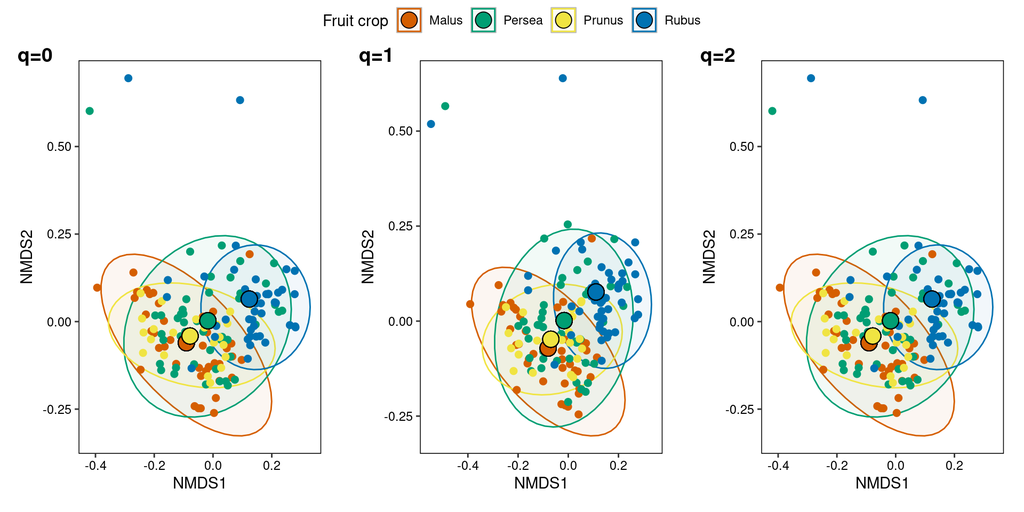

```r
NMDS_scores_q0$Group <- sub(" .*", "", NMDS_scores_q0$Group)
NMDS_scores_q1$Group <- sub(" .*", "", NMDS_scores_q1$Group)
NMDS_scores_q2$Group <- sub(" .*", "", NMDS_scores_q2$Group)

nmds_q0_fruitcrop_plot <- ggplot(NMDS_scores_q0,
    aes(x = NMDS1, y = NMDS2, colour = Group,
        fill = Group)) + stat_ellipse(geom = "polygon",
    alpha = 0.05) + geom_point(size = 2) + geom_point(data = NMDS_scores_q0,
    aes(x = x_cen, y = y_cen, fill = Group), shape = 21,
    colour = "black", size = 5, show.legend = TRUE) +
    crop_color + crop_fill + ord_theme + theme(panel.background = element_rect(fill = "white",
    colour = "grey"))

nmds_q1_fruitcrop_plot <- ggplot(NMDS_scores_q1,
    aes(x = NMDS1, y = NMDS2, colour = Group,
        fill = Group)) + stat_ellipse(geom = "polygon",
    alpha = 0.05) + geom_point(size = 2) + geom_point(data = NMDS_scores_q1,
    aes(x = x_cen, y = y_cen, fill = Group), shape = 21,
    colour = "black", size = 5, show.legend = TRUE) +
    crop_color + crop_fill + ord_theme + theme(panel.background = element_rect(fill = "white",
    colour = "grey"))

nmds_q2_fruitcrop_plot <- ggplot(NMDS_scores_q2,
    aes(x = NMDS1, y = NMDS2, colour = Group,
        fill = Group)) + stat_ellipse(geom = "polygon",
    alpha = 0.05) + geom_point(size = 2) + geom_point(data = NMDS_scores_q2,
    aes(x = x_cen, y = y_cen, fill = Group), shape = 21,
    colour = "black", size = 5, show.legend = TRUE) +
    crop_color + crop_fill + ord_theme + theme(panel.background = element_rect(fill = "white",
    colour = "grey"))

ggarrange(nmds_q0_fruitcrop_plot, nmds_q1_fruitcrop_plot,
    nmds_q2_fruitcrop_plot, nrow = 1, labels = c("q=0",
        "q=1", "q=2"), common.legend = TRUE)
```

NMDS values for insect group plot

```r
NMDS_scores_q0 <- data.frame(NMDS1 = values_NMDS_q0$point[,
    1], NMDS2 = values_NMDS_q0$point[, 2], NMDS3 = values_NMDS_q0$point[,
    3], NMDS4 = values_NMDS_q0$point[, 4], Group = as.factor(pollen_hier_crop[,
    5]))

NMDS_centroids_q0 = aggregate(NMDS_scores_q0[,
    c(1:2)], by = list(NMDS_scores_q0[, 5]), FUN = mean)

table(NMDS_scores_q0$Group)
```

```
##
##          Apis        Bombus Non-Syrphidae         Other     Syrphidae
##            69            42            12            11            22
```

```r
NMDS_scores_q0$Sample <- rownames(NMDS_scores_q0)

colnames(NMDS_centroids_q0) <- c("Group", "x_cen",
    "y_cen")

NMDS_scores_q0 <- merge(NMDS_scores_q0, NMDS_centroids_q0,
    by = "Group")


NMDS_scores_q1 <- data.frame(NMDS1 = values_NMDS_q1$point[,
    1], NMDS2 = values_NMDS_q1$point[, 2], NMDS3 = values_NMDS_q1$point[,
    3], NMDS4 = values_NMDS_q1$point[, 4], Group = as.factor(pollen_hier_crop[,
    5]))
NMDS_centroids_q1 = aggregate(NMDS_scores_q1[,
    c(1:2)], by = list(NMDS_scores_q1[, 5]), FUN = mean)


NMDS_scores_q1$Sample <- rownames(NMDS_scores_q1)

colnames(NMDS_centroids_q1) <- c("Group", "x_cen",
    "y_cen")

NMDS_scores_q1 <- merge(NMDS_scores_q1, NMDS_centroids_q1,
    by = "Group")

NMDS_scores_q2 <- data.frame(NMDS1 = values_NMDS_q2$point[,
    1], NMDS2 = values_NMDS_q2$point[, 2], NMDS3 = values_NMDS_q2$point[,
    3], NMDS4 = values_NMDS_q2$point[, 4], Group = as.factor(pollen_hier_crop[,
    5]))
NMDS_centroids_q2 = aggregate(NMDS_scores_q2[,
    c(1:2)], by = list(NMDS_scores_q2[, 5]), FUN = mean)

NMDS_scores_q2$Sample <- rownames(NMDS_scores_q2)

colnames(NMDS_centroids_q2) <- c("Group", "x_cen",
    "y_cen")

NMDS_scores_q2 <- merge(NMDS_scores_q2, NMDS_centroids_q2,
    by = "Group")
```

Plot NMDS results clustering Insect group using Occurrance data

```r
table(NMDS_scores_q0$Group)
```

```
##
##          Apis        Bombus Non-Syrphidae         Other     Syrphidae
##            69            42            12            11            22
```

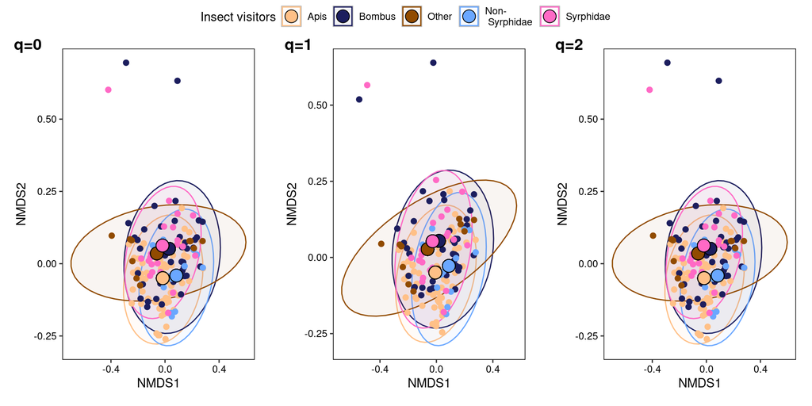

```r
NMDS_scores_q0$Group <- sub(" .*", "", NMDS_scores_q0$Group)
NMDS_scores_q1$Group <- sub(" .*", "", NMDS_scores_q1$Group)
NMDS_scores_q2$Group <- sub(" .*", "", NMDS_scores_q2$Group)

nmds_q0_bichos_plot <- ggplot(NMDS_scores_q0,
    aes(x = NMDS1, y = NMDS2, colour = Group,
        fill = Group)) + stat_ellipse(geom = "polygon",
    alpha = 0.05) + geom_point(size = 2) + geom_point(data = NMDS_scores_q0,
    aes(x = x_cen, y = y_cen, fill = Group), shape = 21,
    colour = "black", size = 5, show.legend = TRUE) +
    bichos_color + bichos_fill + ord_theme + theme(panel.background = element_rect(fill = "white",
    colour = "grey"))

nmds_q1_bichos_plot <- ggplot(NMDS_scores_q1,
    aes(x = NMDS1, y = NMDS2, colour = Group,
        fill = Group)) + stat_ellipse(geom = "polygon",
    alpha = 0.05) + geom_point(size = 2) + geom_point(data = NMDS_scores_q1,
    aes(x = x_cen, y = y_cen, fill = Group), shape = 21,
    colour = "black", size = 5, show.legend = TRUE) +
    bichos_color + bichos_fill + ord_theme + theme(panel.background = element_rect(fill = "white",
    colour = "grey"))

nmds_q2_bichos_plot <- ggplot(NMDS_scores_q2,
    aes(x = NMDS1, y = NMDS2, colour = Group,
        fill = Group)) + stat_ellipse(geom = "polygon",
    alpha = 0.05) + geom_point(size = 2) + geom_point(data = NMDS_scores_q2,
    aes(x = x_cen, y = y_cen, fill = Group), shape = 21,
    colour = "black", size = 5, show.legend = TRUE) +
    bichos_color + bichos_fill + ord_theme + theme(panel.background = element_rect(fill = "white",
    colour = "grey"))

ggarrange(nmds_q0_bichos_plot, nmds_q1_bichos_plot,
    nmds_q2_bichos_plot, nrow = 1, labels = c("q=0",
        "q=1", "q=2"), common.legend = TRUE)
```

Figure 4

```r
png(paste0(outputDir, "/Figures/Figure4.png"),
    width = 3000, height = 2800, res = 300)

pushViewport(viewport(layout = grid.layout(30,
    12)))
vplayout <- function(x, y) viewport(layout.pos.row = x,
    layout.pos.col = y)

print(alpha_pollen_fruitcrops_p + theme(plot.title = element_text(size = 20,
    hjust = 0.01, vjust = -3, face = "bold", family = "Helvetica")) +
    ggtitle("a."), vp = vplayout(1:9, 1:12))

print(alpha_pollen_bichos_p + theme(plot.title = element_text(size = 20,
    hjust = 0.01, vjust = -3, face = "bold", family = "Helvetica")) +
    ggtitle("b."), vp = vplayout(9:18, 1:12))

print(nmds_q1_fruitcrop_plot + theme(legend.position = "right",
    plot.title = element_text(size = 20, hjust = -0.1,
        vjust = 1, face = "bold", family = "Helvetica")) +
    ggtitle("c."), vp = vplayout(18:30, 1:6))

print(nmds_q1_bichos_plot + theme(legend.position = "right",
    plot.title = element_text(size = 20, hjust = -0.2,
        vjust = 1, face = "bold", family = "Helvetica")) +
    ggtitle("d."), vp = vplayout(18:30, 7:12))

dev.off()
```

## Session Info

```r
sessioninfo::session_info() %>%
    details::details(summary = "Current session info",
        open = FALSE)
```

**Current session info**

```r
─ Session info ───────────────────────────────────────────────────────────────
 setting  value
 version  R version 4.3.3 (2024-02-29)
 os       Linux Mint 21.3
 system   x86_64, linux-gnu
 ui       X11
 language en_US
 collate  en_IN.UTF-8
 ctype    en_IN.UTF-8
 tz       Europe/Berlin
 date     2024-05-02
 pandoc   3.1.13 @ /usr/local/bin/ (via rmarkdown)

─ Packages ───────────────────────────────────────────────────────────────────
 package           * version    date (UTC) lib source
 abind               1.4-5      2016-07-21 [1] CRAN (R 4.3.0)
 ade4                1.7-22     2023-02-06 [1] CRAN (R 4.3.0)
 ape                 5.7-1      2023-03-13 [1] CRAN (R 4.3.0)
 backports           1.4.1      2021-12-13 [1] CRAN (R 4.3.0)
 base64enc           0.1-3      2015-07-28 [1] CRAN (R 4.3.0)
 bbmle               1.0.25     2022-05-11 [1] CRAN (R 4.3.0)
 bdsmatrix           1.3-6      2022-06-03 [1] CRAN (R 4.3.0)
 Biobase             2.62.0     2023-10-24 [1] Bioconductor
 BiocGenerics      * 0.48.0     2023-10-24 [1] Bioconductor
 biomformat          1.30.0     2023-10-24 [1] Bioconductor
 Biostrings        * 2.70.1     2023-10-25 [1] Bioconductor
 bitops              1.0-7      2021-04-24 [1] CRAN (R 4.3.0)
 broom               1.0.5      2023-06-09 [1] CRAN (R 4.3.1)
 bslib               0.5.1      2023-08-11 [1] CRAN (R 4.3.1)
 cachem              1.0.8      2023-05-01 [1] CRAN (R 4.3.0)
 car                 3.1-2      2023-03-30 [1] CRAN (R 4.3.0)
 carData             3.0-5      2022-01-06 [1] CRAN (R 4.3.0)
 checkmate           2.2.0      2023-04-27 [1] CRAN (R 4.3.0)
 cli                 3.6.2      2023-12-11 [1] CRAN (R 4.3.3)
 clipr               0.8.0      2022-02-22 [1] CRAN (R 4.3.0)
 cluster             2.1.4      2022-08-22 [1] CRAN (R 4.3.0)
 clusterGeneration   1.3.8      2023-08-16 [1] CRAN (R 4.3.1)
 coda                0.19-4     2020-09-30 [1] CRAN (R 4.3.1)
 codetools           0.2-19     2023-02-01 [1] CRAN (R 4.3.0)
 colorspace          2.1-0      2023-01-23 [1] CRAN (R 4.3.0)
 combinat            0.0-8      2012-10-29 [1] CRAN (R 4.3.1)
 corpcor             1.6.10     2021-09-16 [1] CRAN (R 4.3.1)
 cowplot           * 1.1.1      2020-12-30 [1] CRAN (R 4.3.0)
 crayon              1.5.2      2022-09-29 [1] CRAN (R 4.3.0)
 data.table          1.14.8     2023-02-17 [1] CRAN (R 4.3.0)
 desc                1.4.2      2022-09-08 [1] CRAN (R 4.3.0)
 deSolve             1.38       2023-09-05 [1] CRAN (R 4.3.1)
 details           * 0.3.0      2022-03-27 [1] CRAN (R 4.3.0)
 digest              0.6.35     2024-03-11 [1] CRAN (R 4.3.3)
 doParallel          1.0.17     2022-02-07 [1] CRAN (R 4.3.0)
 doSNOW              1.0.20     2022-02-04 [1] CRAN (R 4.3.0)
 dplyr             * 1.1.4      2023-11-17 [1] CRAN (R 4.3.3)
 eulerr              7.0.0      2022-12-10 [1] CRAN (R 4.3.0)
 evaluate            0.23       2023-11-01 [1] CRAN (R 4.3.2)
 expm                0.999-7    2023-01-09 [1] CRAN (R 4.3.1)
 fansi               1.0.6      2023-12-08 [1] CRAN (R 4.3.3)
 fantaxtic         * 0.2.0      2023-09-05 [1] Github (gmteunisse/fantaxtic@7b422c5)
 farver              2.1.1      2022-07-06 [1] CRAN (R 4.3.0)
 fastmap             1.1.1      2023-02-24 [1] CRAN (R 4.3.0)
 fastmatch           1.1-4      2023-08-18 [1] CRAN (R 4.3.1)
 fdrtool             1.2.17     2021-11-13 [1] CRAN (R 4.3.1)
 forcats           * 1.0.0      2023-01-29 [1] CRAN (R 4.3.0)
 foreach             1.5.2      2022-02-02 [1] CRAN (R 4.3.0)
 foreign             0.8-84     2022-12-06 [1] CRAN (R 4.3.0)
 formatR             1.14       2023-01-17 [1] CRAN (R 4.3.0)
 Formula             1.2-5      2023-02-24 [1] CRAN (R 4.3.0)
 FSA                 0.9.5      2023-08-26 [1] CRAN (R 4.3.1)
 geiger              2.0.11     2023-04-03 [1] CRAN (R 4.3.1)
 generics            0.1.3      2022-07-05 [1] CRAN (R 4.3.0)
 GenomeInfoDb      * 1.38.0     2023-10-24 [1] Bioconductor
 GenomeInfoDbData    1.2.11     2023-10-26 [1] Bioconductor
 ggh4x             * 0.2.6      2023-08-30 [1] CRAN (R 4.3.2)
 ggnested            0.1.0      2023-09-05 [1] Github (gmteunisse/ggnested@70ca146)
 ggplot2           * 3.5.1      2024-04-23 [1] CRAN (R 4.3.3)
 ggpubr            * 0.6.0      2023-02-10 [1] CRAN (R 4.3.0)
 ggrepel             0.9.4      2023-10-13 [1] CRAN (R 4.3.1)
 ggsignif            0.6.4      2022-10-13 [1] CRAN (R 4.3.0)
 ggtext            * 0.1.2      2022-09-16 [1] CRAN (R 4.3.1)
 glasso              1.11       2019-10-01 [1] CRAN (R 4.3.1)
 glue                1.7.0      2024-01-09 [1] CRAN (R 4.3.3)
 gridExtra           2.3        2017-09-09 [1] CRAN (R 4.3.0)
 gridtext            0.1.5      2022-09-16 [1] CRAN (R 4.3.1)
 gtable            * 0.3.5      2024-04-22 [1] CRAN (R 4.3.3)
 gtools              3.9.4      2022-11-27 [1] CRAN (R 4.3.1)
 highr               0.10       2022-12-22 [1] CRAN (R 4.3.0)
 hilldiv           * 1.5.3      2023-10-13 [1] Github (anttonalberdi/hilldiv@551c284)
 Hmisc               5.1-1      2023-09-12 [1] CRAN (R 4.3.1)
 hms                 1.1.3      2023-03-21 [1] CRAN (R 4.3.0)
 htmlTable           2.4.1      2022-07-07 [1] CRAN (R 4.3.0)
 htmltools           0.5.7      2023-11-03 [1] CRAN (R 4.3.2)
 htmlwidgets         1.6.2      2023-03-17 [1] CRAN (R 4.3.0)
 httr                1.4.7      2023-08-15 [1] CRAN (R 4.3.2)
 igraph              1.5.1      2023-08-10 [1] CRAN (R 4.3.1)
 iNEXT             * 3.0.0      2022-08-29 [1] CRAN (R 4.3.1)
 IRanges           * 2.36.0     2023-10-24 [1] Bioconductor
 iterators           1.0.14     2022-02-05 [1] CRAN (R 4.3.0)
 jpeg                0.1-10     2022-11-29 [1] CRAN (R 4.3.0)
 jquerylib           0.1.4      2021-04-26 [1] CRAN (R 4.3.0)
 jsonlite            1.8.7      2023-06-29 [1] CRAN (R 4.3.1)
 kableExtra        * 1.3.4.9000 2023-06-03 [1] Github (haozhu233/kableExtra@292f607)
 knitr             * 1.45       2023-10-30 [1] CRAN (R 4.3.2)
 labeling            0.4.3      2023-08-29 [1] CRAN (R 4.3.1)
 lattice           * 0.21-8     2023-04-05 [1] CRAN (R 4.3.0)
 lavaan              0.6-16     2023-07-19 [1] CRAN (R 4.3.1)
 lifecycle           1.0.4      2023-11-07 [1] CRAN (R 4.3.2)
 lubridate         * 1.9.2      2023-02-10 [1] CRAN (R 4.3.0)
 magrittr          * 2.0.3      2022-03-30 [1] CRAN (R 4.3.0)
 maps                3.4.1      2022-10-30 [1] CRAN (R 4.3.0)
 MASS                7.3-60     2023-05-04 [1] CRAN (R 4.3.0)
 Matrix              1.5-4.1    2023-05-18 [1] CRAN (R 4.3.0)
 mgcv                1.8-42     2023-03-02 [1] CRAN (R 4.3.0)
 MicEco            * 0.9.19     2023-06-03 [1] Github (Russel88/MicEco@91f8e6f)
 microbiome        * 1.24.0     2023-10-24 [1] Bioconductor
 microViz          * 0.11.0     2023-10-27 [1] Github (david-barnett/microViz@11cdd44)
 mnormt              2.1.1      2022-09-26 [1] CRAN (R 4.3.1)
 multtest            2.58.0     2023-10-24 [1] Bioconductor
 munsell             0.5.1      2024-04-01 [1] CRAN (R 4.3.3)
 mvtnorm             1.2-3      2023-08-25 [1] CRAN (R 4.3.1)
 nlme                3.1-162    2023-01-31 [1] CRAN (R 4.3.0)
 nnet                7.3-19     2023-05-03 [1] CRAN (R 4.3.0)
 numDeriv            2016.8-1.1 2019-06-06 [1] CRAN (R 4.3.0)
 optimParallel       1.0-2      2021-02-11 [1] CRAN (R 4.3.1)
 pbapply             1.7-2      2023-06-27 [1] CRAN (R 4.3.1)
 pbivnorm            0.6.0      2015-01-23 [1] CRAN (R 4.3.1)
 permute           * 0.9-7      2022-01-27 [1] CRAN (R 4.3.0)
 phangorn            2.11.1     2023-01-23 [1] CRAN (R 4.3.0)
 pheatmap            1.0.12     2019-01-04 [1] CRAN (R 4.3.0)
 phyloseq          * 1.44.0     2023-06-03 [1] bioc_git2r (@03b74f7)
 phytools            1.9-16     2023-07-14 [1] CRAN (R 4.3.1)
 picante             1.8.2      2020-06-10 [1] CRAN (R 4.3.0)
 pillar              1.9.0      2023-03-22 [1] CRAN (R 4.3.0)
 pkgconfig           2.0.3      2019-09-22 [1] CRAN (R 4.3.0)
 plotrix             3.8-2      2021-09-08 [1] CRAN (R 4.3.1)
 plotwidgets         0.5.1      2022-05-10 [1] CRAN (R 4.3.1)
 plyr                1.8.9      2023-10-02 [1] CRAN (R 4.3.1)
 png               * 0.1-8      2022-11-29 [1] CRAN (R 4.3.2)
 psych               2.3.9      2023-09-26 [1] CRAN (R 4.3.1)
 purrr             * 1.0.2      2023-08-10 [1] CRAN (R 4.3.1)
 qgraph              1.9.5      2023-05-16 [1] CRAN (R 4.3.1)
 quadprog            1.5-8      2019-11-20 [1] CRAN (R 4.3.0)
 R6                  2.5.1      2021-08-19 [1] CRAN (R 4.3.0)
 RColorBrewer        1.1-3      2022-04-03 [1] CRAN (R 4.3.0)
 Rcpp                1.0.12     2024-01-09 [1] CRAN (R 4.3.3)
 RCurl               1.98-1.12  2023-03-27 [1] CRAN (R 4.3.0)
 readr             * 2.1.4      2023-02-10 [1] CRAN (R 4.3.0)
 reshape2            1.4.4      2020-04-09 [1] CRAN (R 4.3.0)
 rhdf5               2.46.0     2023-10-24 [1] Bioconductor
 rhdf5filters        1.14.0     2023-10-24 [1] Bioconductor
 Rhdf5lib            1.24.0     2023-10-24 [1] Bioconductor
 rlang               1.1.3      2024-01-10 [1] CRAN (R 4.3.3)
 rmarkdown           2.25       2023-09-18 [1] CRAN (R 4.3.1)
 rpart               4.1.19     2022-10-21 [1] CRAN (R 4.3.0)
 rprojroot           2.0.3      2022-04-02 [1] CRAN (R 4.3.0)
 rstatix             0.7.2      2023-02-01 [1] CRAN (R 4.3.0)
 rstudioapi          0.15.0     2023-07-07 [1] CRAN (R 4.3.1)
 Rtsne               0.16       2022-04-17 [1] CRAN (R 4.3.0)
 rvest               1.0.3      2022-08-19 [1] CRAN (R 4.3.0)
 S4Vectors         * 0.40.0     2023-10-24 [1] Bioconductor
 sass                0.4.7      2023-07-15 [1] CRAN (R 4.3.1)
 scales              1.3.0      2023-11-28 [1] CRAN (R 4.3.3)
 scatterplot3d       0.3-44     2023-05-05 [1] CRAN (R 4.3.1)
 sessioninfo         1.2.2      2021-12-06 [1] CRAN (R 4.3.0)
 snow                0.4-4      2021-10-27 [1] CRAN (R 4.3.0)
 stringi             1.8.3      2023-12-11 [1] CRAN (R 4.3.3)
 stringr           * 1.5.1      2023-11-14 [1] CRAN (R 4.3.3)
 subplex             1.8        2022-04-12 [1] CRAN (R 4.3.1)
 survival            3.5-5      2023-03-12 [1] CRAN (R 4.3.0)
 svglite             2.1.1      2023-01-10 [1] CRAN (R 4.3.0)
 systemfonts         1.0.5      2023-10-09 [1] CRAN (R 4.3.1)
 tibble            * 3.2.1      2023-03-20 [1] CRAN (R 4.3.0)
 tidyr             * 1.3.0      2023-01-24 [1] CRAN (R 4.3.0)
 tidyselect          1.2.1      2024-03-11 [1] CRAN (R 4.3.3)
 tidyverse         * 2.0.0      2023-02-22 [1] CRAN (R 4.3.0)
 timechange          0.2.0      2023-01-11 [1] CRAN (R 4.3.0)
 tzdb                0.4.0      2023-05-12 [1] CRAN (R 4.3.0)
 utf8                1.2.4      2023-10-22 [1] CRAN (R 4.3.1)
 vctrs               0.6.5      2023-12-01 [1] CRAN (R 4.3.3)
 vegan             * 2.6-4      2022-10-11 [1] CRAN (R 4.3.0)
 viridisLite         0.4.2      2023-05-02 [1] CRAN (R 4.3.0)
 webshot             0.5.4      2022-09-26 [1] CRAN (R 4.3.0)
 withr               3.0.0      2024-01-16 [1] CRAN (R 4.3.3)
 xfun                0.43       2024-03-25 [1] CRAN (R 4.3.3)
 xml2                1.3.6      2023-12-04 [1] CRAN (R 4.3.3)
 XVector           * 0.42.0     2023-10-24 [1] Bioconductor
 yaml                2.3.7      2023-01-23 [1] CRAN (R 4.3.0)
 zlibbioc            1.48.0     2023-10-24 [1] Bioconductor

 [1] /home/kari/R/x86_64-pc-linux-gnu-library/4.3
 [2] /usr/local/lib/R/site-library
 [3] /usr/lib/R/site-library
 [4] /usr/lib/R/library

──────────────────────────────────────────────────────────────────────────────
```